# ESM 244 Lab Week 4 Key

Allison Horst

January 28, 2019

Lab Week 4:

- Nonlinear least squares
- Panel regression level 0 example
- Shiny example with navbarPage

```r
library(tidyverse)
library(Ecdat)
library(plm)
library(lmtest)
```

```r
library(car) #for plotting
```

### Part 1. Nonlinear least squares (logistic growth fitting)

1. Load dataset CellGrowth.csv. Create a scatterplot.

```r
CellGrowth <- read_csv("CellGrowth.csv")
```

2. Look at it

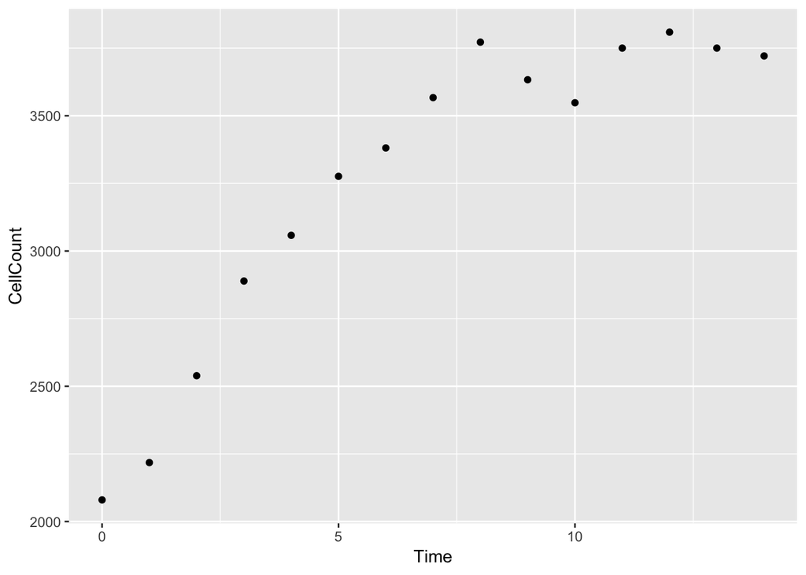

```r
ggplot(CellGrowth, aes(x = Time, y = CellCount)) + geom_point()
```

Recall logistic growth equation:

N(t) = A/(1+Be^-rt)

# Estimate for K/A: ~ 3700

# Estimate for N0: ~ 2000

# Estimate for B: ~ 0.85

BEstimate <- (3700 - 2000)/2000 # BEstimate = 0.85

3. Create a subset of the data that you think is just in the ‘exponential growth phase.’ Take the natural log of the count and create a basic scatterplot of time v ln(counts).

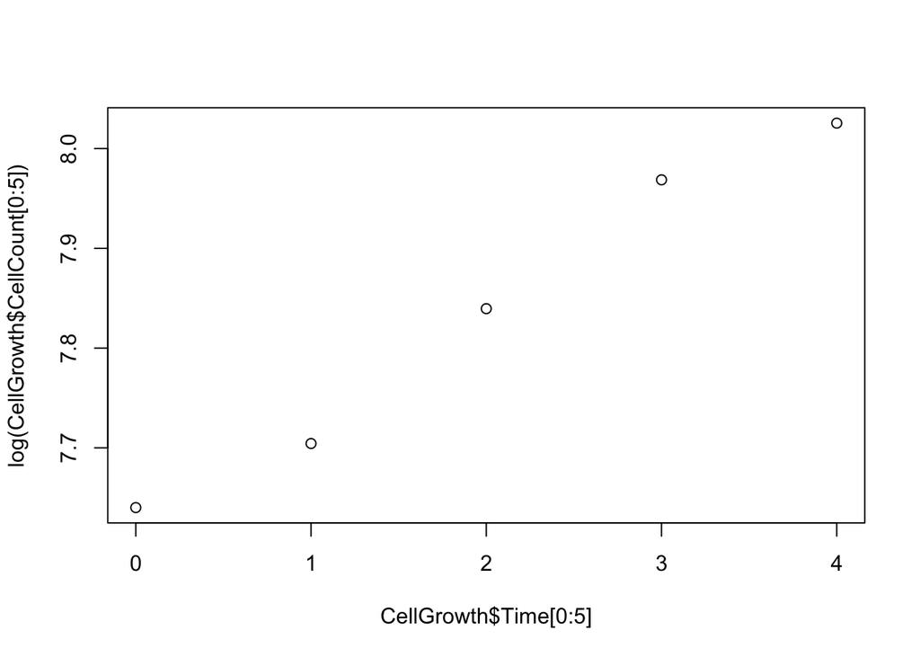

```r
Graph2 <- plot(CellGrowth$Time[0:5],log(CellGrowth$CellCount[0:5])) # Create a basic scatterplot of time versus ln(CellCounts)
```

Then find the slope of that line to get ‘r’ (growth rate constant)

```r
r_est <- lm(log(CellGrowth$CellCount[1:5]) ~ CellGrowth$Time[1:5]) # R ~ 0.1035
```

4. Nonlinear least squares
5. Model fitting

```r
cell_fit <- nls(CellCount ~ A/(1+B*exp(-r*Time)),
                start = list(A = 3700, B = 0.85, r = 0.1035),
                data = CellGrowth, trace = TRUE)
```

```
## 7996304 :  3700.0000    0.8500    0.1035
## 7595140 :  3293.8084442    0.6431423    0.1437013
## 5307698 :  3197.140704    0.595545    0.215801
## 1494838 :  3436.8256143    0.7253421    0.3060712
## 88027.23 :  3802.4852184    0.9209577    0.3501814
## 87191.74 :  3806.5481869    0.9228920    0.3435714
## 87187.73 :  3805.8080711    0.9233090    0.3443107
## 87187.7 :  3805.8993927    0.9232887    0.3442454
## 87187.7 :  3805.8912348    0.9232910    0.3442515
```

Uses the estimates as a start to find the best estimated values (by convergence) for A, B and r

8 iterations for convergence Estimates, St. Errors and p-values

6. Create new variables for A, B and r

```r
A <- coef(cell_fit)[1]
B <- coef(cell_fit)[2]
r <- coef(cell_fit)[3]
```

7. Create a new sequence containing a series of times over which you’ll predict the cell count

```r
time_seq <- seq(0,20, length = 100)
```

8. Using the parameters (A, B, and r) and the time sequence, predict the cell counts for the logistic growth model

```r
cell_pred <- A/(1+B*exp(-r*time_seq)) # Logistic growth model
```

1. Bind together the time sequence data and the predictions data into a new data frame

```r
pred_df <- data.frame(time_seq, cell_pred)
```

10. Create a single graph in which you show the original data (as scatterplot points) and the predicted data (as a line graph)

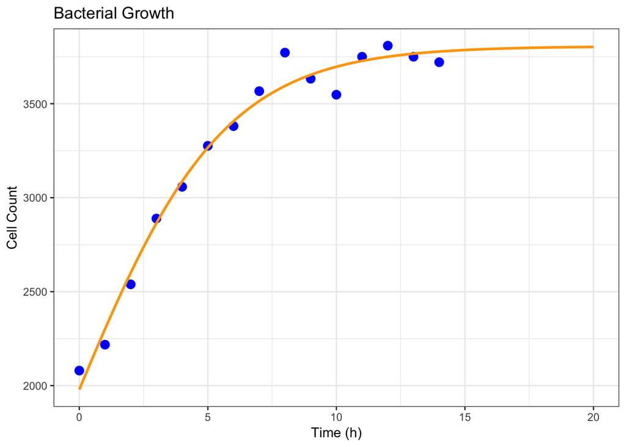

```r
ggplot(CellGrowth, aes(x = Time, y = CellCount)) +
  geom_point(colour = "blue", size = 3) +
  theme_bw() +
  geom_line(data = pred_df, aes(x = time_seq, y = cell_pred), colour = "orange", size = 1) +
  xlab("Time (h)") +
  ylab("Cell Count") +
  ggtitle("Bacterial Growth")
```

### Part 2. Panel Regression - First Shot

The Data:

This data and example came from the Ecdat package in R: https://cran.r-project.org/web/packages/Ecdat/Ecdat.pdf

- state (our “entity”)
- year (time)
- packpc (the number of packs per capita- our DV)
- avgprs (average price during fiscal year, including sales taxes- our IV)

```r
cigs_panel <- Cigarette %>%
  select(state, year, packpc, avgprs) #only retaining the 4 columns we're interested in
```